```python
import numpy as np
import pandas as pd
import datetime as dt
```

# Exercise #1 - Data Cleaning

```python
df=pd.read_csv('Food_Inspection.csv')
df.head()
```

|  | Establishment ID | Name | Address 1 | Address 2 | City | Zip | Inspection Date | Inspection Results | Food from Approved Source (C) | Food Protected from Contamination (C) | ... | Nutritional Labeling | Trans Fat Ban | No-Smoking Sign Posted | Inspection Type | Owner | Category | Type | Latitude | Longitude | Location |
| --- | --- | --- | --- | --- | --- | --- | --- | --- | --- | --- | --- | --- | --- | --- | --- | --- | --- | --- | --- | --- | --- |
| 0 | 18628 | SUBWAY #22916 | 12193 DARNESTOWN RD. | NaN | GAITHERSBURG | 20878 | 12/19/2018 | No Critical Violations Noted | In Compliance | In Compliance | ... | Not applicable | In Compliance | In Compliance | Monitoring | P. N. ENTERPRISES, LLC | Restaurant | Food | 39.1179 | -77.2524 | (39.1179, -77.2524) |
| 1 | 1059 | GIANT FOOD #0192 | 18250 FLOWER HILL WAY | NaN | GAITHERSBURG | 20879 | 12/19/2018 | Critical Violations Corrected | In Compliance | In Compliance | ... | Not applicable | In Compliance | In Compliance | Comprehensive | GIANT OF MARYLAND, LLC | Market | Food | 39.1551 | -77.1659 | (39.1551, -77.1659) |
| 2 | 20933 | PIZZA BOLIS | 7831 EASTERN AVE. | NaN | SILVER SPRING | 20910 | 12/19/2018 | No Critical Violations Noted | In Compliance | In Compliance | ... | Not applicable | In Compliance | In Compliance | Monitoring | K.M.MG INC | Restaurant | Food | 38.9853 | -77.0273 | (38.9853, -77.0273) |
| 3 | 22217 | GREENE TURTLE | 18101 TOWN CENTER DR | NaN | OLNEY | 20832 | 12/13/2017 | No Critical Violations Noted | In Compliance | In Compliance | ... | Not applicable | In Compliance | In Compliance | Comprehensive | OLNEY GT, LLC. | Restaurant | Food | 39.1519 | -77.0619 | (39.1519, -77.0619) |
| 4 | 28408 | CRAVE | 7101 DEMOCRACY BLVD | SPACE #FC | BETHESDA | 20817 | 12/13/2018 | No Critical Violations Noted | In Compliance | In Compliance | ... | Not applicable | In Compliance | In Compliance | Monitoring | CRAVE RESTAURANT BETHESDA LLC | Restaurant | Food | 39.0221 | -77.1471 | (39.0221, -77.1471) |

5 rows × 31 columns

```python
df.columns
```

```
Index(['Establishment ID', 'Name', 'Address 1', 'Address 2', 'City', 'Zip',
       'Inspection Date', 'Inspection Results',
       'Food from Approved Source (C)',
       'Food Protected from Contamination (C)', 'Ill Workers Restricted (C)',
       'Proper Hand Washing (C)', 'Cooling Time and Temperature (C)',
       'Cold Holding Temperature (C)', 'Hot Holding Temperature (C)',
       'Cooking Time and Temperature (C)',
       'Reheating Time and Temperature (C)',
       'Hot and Cold Running Water Provided (C)', 'Proper Sewage Disposal (C)',
       'Toxic Substances & Pesticides', 'Rodent and Insects',
       'Nutritional Labeling', 'Trans Fat Ban', 'No-Smoking Sign Posted',
       'Inspection Type', 'Owner', 'Category', 'Type', 'Latitude', 'Longitude',
       'Location'],
      dtype='object')
```

```python
x=pd.DataFrame(data=df['Category'].unique())
x
```

|  | 0 |
| --- | --- |
| 0 | Restaurant |
| 1 | Market |
| 2 | Caterer |
| 3 | Non-Profit |
| 4 | Public School- Other |
| 5 | NaN |
| 6 | Public School- Elementary |
| 7 | Hospital |
| 8 | Public School- Middle |
| 9 | Assisted Living |
| 10 | Private School |
| 11 | Nursing Home |
| 12 | Public School- High |
| 13 | Carry Out |
| 14 | Farmers Market |
| 15 | Snack Bar |
| 16 | Institution |
| 17 | Excluded Organization |
| 18 | Seasonal |
| 19 | Mobile Unit |

```python
df['Dummy_Restaurant']=0
df.loc[df['Category'] =="Restaurant", 'Dummy_Restaurant'] = 1
df.head()
```

|  | Establishment ID | Name | Address 1 | Address 2 | City | Zip | Inspection Date | Inspection Results | Food from Approved Source (C) | Food Protected from Contamination (C) | ... | Trans Fat Ban | No-Smoking Sign Posted | Inspection Type | Owner | Category | Type | Latitude | Longitude | Location | Dummy_Restaurant |
| --- | --- | --- | --- | --- | --- | --- | --- | --- | --- | --- | --- | --- | --- | --- | --- | --- | --- | --- | --- | --- | --- |
| 0 | 18628 | SUBWAY #22916 | 12193 DARNESTOWN RD. | NaN | GAITHERSBURG | 20878 | 12/19/2018 | No Critical Violations Noted | In Compliance | In Compliance | ... | In Compliance | In Compliance | Monitoring | P. N. ENTERPRISES, LLC | Restaurant | Food | 39.1179 | -77.2524 | (39.1179, -77.2524) | 1 |
| 1 | 1059 | GIANT FOOD #0192 | 18250 FLOWER HILL WAY | NaN | GAITHERSBURG | 20879 | 12/19/2018 | Critical Violations Corrected | In Compliance | In Compliance | ... | In Compliance | In Compliance | Comprehensive | GIANT OF MARYLAND, LLC | Market | Food | 39.1551 | -77.1659 | (39.1551, -77.1659) | 0 |
| 2 | 20933 | PIZZA BOLIS | 7831 EASTERN AVE. | NaN | SILVER SPRING | 20910 | 12/19/2018 | No Critical Violations Noted | In Compliance | In Compliance | ... | In Compliance | In Compliance | Monitoring | K.M.MG INC | Restaurant | Food | 38.9853 | -77.0273 | (38.9853, -77.0273) | 1 |
| 3 | 22217 | GREENE TURTLE | 18101 TOWN CENTER DR | NaN | OLNEY | 20832 | 12/13/2017 | No Critical Violations Noted | In Compliance | In Compliance | ... | In Compliance | In Compliance | Comprehensive | OLNEY GT, LLC. | Restaurant | Food | 39.1519 | -77.0619 | (39.1519, -77.0619) | 1 |
| 4 | 28408 | CRAVE | 7101 DEMOCRACY BLVD | SPACE #FC | BETHESDA | 20817 | 12/13/2018 | No Critical Violations Noted | In Compliance | In Compliance | ... | In Compliance | In Compliance | Monitoring | CRAVE RESTAURANT BETHESDA LLC | Restaurant | Food | 39.0221 | -77.1471 | (39.0221, -77.1471) | 1 |

5 rows × 32 columns

I have only selected rows where Category is of type 'Restaurant' while creating a Dummy variable for Restaraunts

## Step 1.2 - Converted the Inspection_date column into a datetime column. Created a new column for the year of the inspection. Create a new column for the month of the inspection. Create a column for the year and month.

```python
df['Inspection Date']= pd.to_datetime(df['Inspection Date'])
df['Inspection Year']=df["Inspection Date"].apply(lambda x: x.strftime('%Y'))
df['Inspection Month']=df["Inspection Date"].apply(lambda x: x.strftime('%m'))
df['Inspection Year and Month']=df["Inspection Date"].apply(lambda x: x.strftime('%Y-%m'))
df=df[['Establishment ID', 'Name', 'Address 1', 'Address 2', 'City', 'Zip',
       'Inspection Date','Inspection Year', 'Inspection Month',
       'Inspection Year and Month','Inspection Results',
       'Food from Approved Source (C)',
       'Food Protected from Contamination (C)', 'Ill Workers Restricted (C)',
       'Proper Hand Washing (C)', 'Cooling Time and Temperature (C)',
       'Cold Holding Temperature (C)', 'Hot Holding Temperature (C)',
       'Cooking Time and Temperature (C)',
       'Reheating Time and Temperature (C)',
       'Hot and Cold Running Water Provided (C)', 'Proper Sewage Disposal (C)',
       'Toxic Substances & Pesticides', 'Rodent and Insects',
       'Nutritional Labeling', 'Trans Fat Ban', 'No-Smoking Sign Posted',
       'Inspection Type', 'Owner', 'Category', 'Type', 'Latitude', 'Longitude',
       'Location','Dummy_Restaurant']]
df.head()
```

|  | Establishment ID | Name | Address 1 | Address 2 | City | Zip | Inspection Date | Inspection Year | Inspection Month | Inspection Year and Month | ... | Trans Fat Ban | No-Smoking Sign Posted | Inspection Type | Owner | Category | Type | Latitude | Longitude | Location | Dummy_Restaurant |
| --- | --- | --- | --- | --- | --- | --- | --- | --- | --- | --- | --- | --- | --- | --- | --- | --- | --- | --- | --- | --- | --- |
| 0 | 18628 | SUBWAY #22916 | 12193 DARNESTOWN RD. | NaN | GAITHERSBURG | 20878 | 2018-12-19 | 2018 | 12 | 2018-12 | ... | In Compliance | In Compliance | Monitoring | P. N. ENTERPRISES, LLC | Restaurant | Food | 39.1179 | -77.2524 | (39.1179, -77.2524) | 1 |
| 1 | 1059 | GIANT FOOD #0192 | 18250 FLOWER HILL WAY | NaN | GAITHERSBURG | 20879 | 2018-12-19 | 2018 | 12 | 2018-12 | ... | In Compliance | In Compliance | Comprehensive | GIANT OF MARYLAND, LLC | Market | Food | 39.1551 | -77.1659 | (39.1551, -77.1659) | 0 |
| 2 | 20933 | PIZZA BOLIS | 7831 EASTERN AVE. | NaN | SILVER SPRING | 20910 | 2018-12-19 | 2018 | 12 | 2018-12 | ... | In Compliance | In Compliance | Monitoring | K.M.MG INC | Restaurant | Food | 38.9853 | -77.0273 | (38.9853, -77.0273) | 1 |
| 3 | 22217 | GREENE TURTLE | 18101 TOWN CENTER DR | NaN | OLNEY | 20832 | 2017-12-13 | 2017 | 12 | 2017-12 | ... | In Compliance | In Compliance | Comprehensive | OLNEY GT, LLC. | Restaurant | Food | 39.1519 | -77.0619 | (39.1519, -77.0619) | 1 |
| 4 | 28408 | CRAVE | 7101 DEMOCRACY BLVD | SPACE #FC | BETHESDA | 20817 | 2018-12-13 | 2018 | 12 | 2018-12 | ... | In Compliance | In Compliance | Monitoring | CRAVE RESTAURANT BETHESDA LLC | Restaurant | Food | 39.0221 | -77.1471 | (39.0221, -77.1471) | 1 |

5 rows × 35 columns

## Step 1.3 - For each column with the type of compliance, e.g. "Rodent and Insects," created a dummy variable that is 1 if the establishment is out of compliance and 0 otherwise. Used np.nan for not applicable. Dropped the string columns (retain only the dummy variables).

```python
df[df=='Not applicable']=np.nan
```

```python
df.columns
```

```
Index(['Establishment ID', 'Name', 'Address 1', 'Address 2', 'City', 'Zip',
       'Inspection Date', 'Inspection Year', 'Inspection Month',
       'Inspection Year and Month', 'Inspection Results',
       'Food from Approved Source (C)',
       'Food Protected from Contamination (C)', 'Ill Workers Restricted (C)',
       'Proper Hand Washing (C)', 'Cooling Time and Temperature (C)',
       'Cold Holding Temperature (C)', 'Hot Holding Temperature (C)',
       'Cooking Time and Temperature (C)',
       'Reheating Time and Temperature (C)',
       'Hot and Cold Running Water Provided (C)', 'Proper Sewage Disposal (C)',
       'Toxic Substances & Pesticides', 'Rodent and Insects',
       'Nutritional Labeling', 'Trans Fat Ban', 'No-Smoking Sign Posted',
       'Inspection Type', 'Owner', 'Category', 'Type', 'Latitude', 'Longitude',
       'Location', 'Dummy_Restaurant'],
      dtype='object')
```

```python
for a,b in enumerate(df.columns):
    if a>=11 and a<=26:
        df.loc[df[b]=="In Compliance",b]=0
        df.loc[df[b]=="Out of Compliance",b]=1
```

```python
df.iloc[:10,11:26]
```

|  | Food from Approved Source (C) | Food Protected from Contamination (C) | Ill Workers Restricted (C) | Proper Hand Washing (C) | Cooling Time and Temperature (C) | Cold Holding Temperature (C) | Hot Holding Temperature (C) | Cooking Time and Temperature (C) | Reheating Time and Temperature (C) | Hot and Cold Running Water Provided (C) | Proper Sewage Disposal (C) | Toxic Substances & Pesticides | Rodent and Insects | Nutritional Labeling | Trans Fat Ban |
| --- | --- | --- | --- | --- | --- | --- | --- | --- | --- | --- | --- | --- | --- | --- | --- |
| 0 | 0 | 0 | 0 | 0 | 0 | 0 | 0 | 0 | 0 | 0 | 0 | 0 | 0 | NaN | 0 |
| 1 | 0 | 0 | 0 | 1 | 1 | 1 | 0 | 0 | 0 | 0 | 0 | 0 | 0 | NaN | 0 |
| 2 | 0 | 0 | 0 | 0 | 0 | 0 | 0 | 0 | 0 | 0 | 0 | 0 | 0 | NaN | 0 |
| 3 | 0 | 0 | 0 | 0 | 0 | 0 | 0 | 0 | 0 | 0 | 0 | 0 | 0 | NaN | 0 |
| 4 | 0 | 0 | 0 | 0 | 0 | 0 | 0 | 0 | 0 | 0 | 0 | 0 | 1 | NaN | 0 |
| 5 | 0 | 0 | 0 | 0 | 0 | 0 | 1 | 0 | 0 | 0 | 0 | 0 | 0 | NaN | 0 |
| 6 | 0 | 0 | 0 | 0 | 0 | 0 | 1 | 0 | 0 | 0 | 0 | 0 | 0 | NaN | 0 |
| 7 | 0 | 0 | 0 | 0 | 0 | 0 | 0 | 0 | 0 | 0 | 0 | 0 | 1 | NaN | 0 |
| 8 | 0 | 0 | 0 | 0 | 0 | 1 | 0 | 0 | 0 | 0 | 0 | 0 | 1 | NaN | 0 |
| 9 | 0 | 0 | 0 | 0 | 0 | 0 | 0 | 0 | 0 | 0 | 0 | 0 | 0 | NaN | 0 |

```python
df2=df.copy()
```

## Step 1.4 - Created a new column that contains the number of violations for that inspection (the number of categories where the establishment was not in compliance). Create a dummy variable that is 1 if the establishment is out of compliance in any category.

```python
sum_list=[]
df2
for i in range(13701):
    add=0
    for a,b in enumerate(df.columns):
        if a>=11 and a<=26:

            if(df.iloc[i,a]==1):
                add=add+1

    sum_list.append(add)
```

```python
df3=pd.DataFrame({'Number of Out of Compliances':sum_list})
df3.head(10)
```

|  | Number of Out of Compliances |
| --- | --- |
| 0 | 0 |
| 1 | 3 |
| 2 | 0 |
| 3 | 0 |
| 4 | 1 |
| 5 | 1 |
| 6 | 1 |
| 7 | 1 |
| 8 | 2 |
| 9 | 0 |

```python
df2=pd.concat([df2, df3], axis=1)
df2['Dummy_Inspection']=0
df2.iloc[:15,26:]
```

|  | No-Smoking Sign Posted | Inspection Type | Owner | Category | Type | Latitude | Longitude | Location | Dummy_Restaurant | Number of Out of Compliances | Dummy_Inspection |
| --- | --- | --- | --- | --- | --- | --- | --- | --- | --- | --- | --- |
| 0 | 0 | Monitoring | P. N. ENTERPRISES, LLC | Restaurant | Food | 39.1179 | -77.2524 | (39.1179, -77.2524) | 1 | 0 | 0 |
| 1 | 0 | Comprehensive | GIANT OF MARYLAND, LLC | Market | Food | 39.1551 | -77.1659 | (39.1551, -77.1659) | 0 | 3 | 0 |
| 2 | 0 | Monitoring | K.M.MG INC | Restaurant | Food | 38.9853 | -77.0273 | (38.9853, -77.0273) | 1 | 0 | 0 |
| 3 | 0 | Comprehensive | OLNEY GT, LLC. | Restaurant | Food | 39.1519 | -77.0619 | (39.1519, -77.0619) | 1 | 0 | 0 |
| 4 | 0 | Monitoring | CRAVE RESTAURANT BETHESDA LLC | Restaurant | Food | 39.0221 | -77.1471 | (39.0221, -77.1471) | 1 | 1 | 0 |
| 5 | 0 | Monitoring | FIRST WATCH RESTAURANTS, INC | Restaurant | Food | 39.1137 | -77.2167 | (39.1137, -77.2167) | 1 | 1 | 0 |
| 6 | 0 | Monitoring | SHIVA DELIGHT INC | Restaurant | Food | 39.0250 | -77.1483 | (39.025, -77.1483) | 1 | 1 | 0 |
| 7 | 0 | Food Complaint | POTOMAC FAMILY DINING GROUP OPERATING COMPANY | Restaurant | Food | 39.2018 | -77.2460 | (39.2018, -77.246) | 1 | 1 | 0 |
| 8 | 0 | Comprehensive | SIRIWAN THAI RESTAURANT, INC. | Restaurant | Food | 39.1095 | -76.9954 | (39.1095, -76.9954) | 1 | 2 | 0 |
| 9 | 0 | Monitoring | DOG HAUS | Restaurant | Food | 38.9866 | -77.0968 | (38.9866, -77.0968) | 1 | 0 | 0 |
| 10 | 0 | Comprehensive | DELIGHTS FOODS, INC | Restaurant | Food | 39.1528 | -77.0613 | (39.1528, -77.0613) | 1 | 0 | 0 |
| 11 | 0 | Food Complaint | CHOPOTLE MEXICAN GRILL OF COLORADO LLC | Restaurant | Food | 39.0370 | -77.0539 | (39.037, -77.0539) | 1 | 0 | 0 |
| 12 | 0 | Environmental | RITE AID OF MARYLAND, INC. | Market | Food | 38.9946 | -77.0330 | (38.9946, -77.033) | 0 | 0 | 0 |
| 13 | 0 | Comprehensive | JANAKARORA ASHWANIRORA | Caterer | Food | 39.1419 | -77.1904 | (39.1419, -77.1904) | 0 | 2 | 0 |
| 14 | 0 | Comprehensive | ISKCON OF D. C. INC. | Restaurant | Food | 39.0026 | -77.2132 | (39.0026, -77.2132) | 1 | 2 | 0 |

```python
df2.loc[df2['Number of Out of Compliances'] >0, 'Dummy_Inspection'] = 1
```

```python
df2.head(15)
```

|  | Establishment ID | Name | Address 1 | Address 2 | City | Zip | Inspection Date | Inspection Year | Inspection Month | Inspection Year and Month | ... | Inspection Type | Owner | Category | Type | Latitude | Longitude | Location | Dummy_Restaurant | Number of Out of Compliances | Dummy_Inspection |
| --- | --- | --- | --- | --- | --- | --- | --- | --- | --- | --- | --- | --- | --- | --- | --- | --- | --- | --- | --- | --- | --- |
| 0 | 18628 | SUBWAY #22916 | 12193 DARNESTOWN RD. | NaN | GAITHERSBURG | 20878 | 2018-12-19 | 2018 | 12 | 2018-12 | ... | Monitoring | P. N. ENTERPRISES, LLC | Restaurant | Food | 39.1179 | -77.2524 | (39.1179, -77.2524) | 1 | 0 | 0 |
| 1 | 1059 | GIANT FOOD #0192 | 18250 FLOWER HILL WAY | NaN | GAITHERSBURG | 20879 | 2018-12-19 | 2018 | 12 | 2018-12 | ... | Comprehensive | GIANT OF MARYLAND, LLC | Market | Food | 39.1551 | -77.1659 | (39.1551, -77.1659) | 0 | 3 | 1 |
| 2 | 20933 | PIZZA BOLIS | 7831 EASTERN AVE. | NaN | SILVER SPRING | 20910 | 2018-12-19 | 2018 | 12 | 2018-12 | ... | Monitoring | K.M.MG INC | Restaurant | Food | 38.9853 | -77.0273 | (38.9853, -77.0273) | 1 | 0 | 0 |
| 3 | 22217 | GREENE TURTLE | 18101 TOWN CENTER DR | NaN | OLNEY | 20832 | 2017-12-13 | 2017 | 12 | 2017-12 | ... | Comprehensive | OLNEY GT, LLC. | Restaurant | Food | 39.1519 | -77.0619 | (39.1519, -77.0619) | 1 | 0 | 0 |
| 4 | 28408 | CRAVE | 7101 DEMOCRACY BLVD | SPACE #FC | BETHESDA | 20817 | 2018-12-13 | 2018 | 12 | 2018-12 | ... | Monitoring | CRAVE RESTAURANT BETHESDA LLC | Restaurant | Food | 39.0221 | -77.1471 | (39.0221, -77.1471) | 1 | 1 | 1 |
| 5 | 28011 | FIRST WATCH RESTAURANT #139 | 802 MUDDY BRANCH RD | NaN | GAITHERSBURG | 20878 | 2018-12-19 | 2018 | 12 | 2018-12 | ... | Monitoring | FIRST WATCH RESTAURANTS, INC | Restaurant | Food | 39.1137 | -77.2167 | (39.1137, -77.2167) | 1 | 1 | 1 |
| 6 | 27427 | MIRCH MASALA GRILL | 7101 DEMOCRACY BLVD | SPACE #2340 | BETHESDA | 20817 | 2018-12-18 | 2018 | 12 | 2018-12 | ... | Monitoring | SHIVA DELIGHT INC | Restaurant | Food | 39.0250 | -77.1483 | (39.025, -77.1483) | 1 | 1 | 1 |
| 7 | 22419 | APPLEBEE'S | 21048 FREDERICK RD. | NaN | GERMANTOWN | 20876 | 2017-12-12 | 2017 | 12 | 2017-12 | ... | Food Complaint | POTOMAC FAMILY DINING GROUP OPERATING COMPANY | Restaurant | Food | 39.2018 | -77.2460 | (39.2018, -77.246) | 1 | 1 | 1 |
| 8 | 21231 | SIRIWAN THAI RESTAURANT | 736 CLOVERLY ST. | NaN | SILVER SPRING | 20905 | 2017-12-12 | 2017 | 12 | 2017-12 | ... | Comprehensive | SIRIWAN THAI RESTAURANT, INC. | Restaurant | Food | 39.1095 | -76.9954 | (39.1095, -76.9954) | 1 | 2 | 1 |
| 9 | 30673 | DOG HAUS | 7704 WOODMONT AVE | NaN | BETHESDA | 20814 | 2018-12-18 | 2018 | 12 | 2018-12 | ... | Monitoring | DOG HAUS | Restaurant | Food | 38.9866 | -77.0968 | (38.9866, -77.0968) | 1 | 0 | 0 |
| 10 | 20921 | SUBWAY #18137 | 18137 TOWN CENTER DR. | NaN | OLNEY | 20832 | 2017-12-12 | 2017 | 12 | 2017-12 | ... | Comprehensive | DELIGHTS FOODS, INC | Restaurant | Food | 39.1528 | -77.0613 | (39.1528, -77.0613) | 1 | 0 | 0 |
| 11 | 27452 | CHIPOTLE MEXICAN GRILL #2055 | 11160 VEIRS MILL RD | SPACE P208C | SILVER SPRING | 20902 | 2017-12-13 | 2017 | 12 | 2017-12 | ... | Food Complaint | CHOPOTLE MEXICAN GRILL OF COLORADO LLC | Restaurant | Food | 39.0370 | -77.0539 | (39.037, -77.0539) | 1 | 0 | 0 |
| 12 | 2097 | RITE AID #04597 | 1411 EAST-WEST HWY. | NaN | SILVER SPRING | 20910 | 2017-12-13 | 2017 | 12 | 2017-12 | ... | Environmental | RITE AID OF MARYLAND, INC. | Market | Food | 38.9946 | -77.0330 | (38.9946, -77.033) | 0 | 0 | 0 |
| 13 | 19393 | NATRAJ RESTAURANT CATERER | 403 E. DIAMOND AVE | NaN | GAITHERSBURG | 20877 | 2018-12-18 | 2018 | 12 | 2018-12 | ... | Comprehensive | JANAKARORA ASHWANIRORA | Caterer | Food | 39.1419 | -77.1904 | (39.1419, -77.1904) | 0 | 2 | 1 |
| 14 | 1264 | ISKCON CHURCH | 10310 OAKLYN RD. | NaN | POTOMAC | 20854 | 2018-12-13 | 2018 | 12 | 2018-12 | ... | Comprehensive | ISKCON OF D. C. INC. | Restaurant | Food | 39.0026 | -77.2132 | (39.0026, -77.2132) | 1 | 2 | 1 |

15 rows × 37 columns

## Step 1.5 - For establishments with multiple inspections, created a new DataFrame in wide format. Kept only the establishment ID, Category, Inspection_date, and number of violations. Made sure category is consistent within ID and resolved any discrepancies if necessary (i.e. each establishment has only one category). Reshaped from long to wide (pivot) such that each establishment is a row and you have a column for the date and number of violations for inspection 1, inspection 2, inspection 3, etc.

```python
dfu=df2[['Establishment ID','Name','Inspection Date','Number of Out of Compliances']]
dfu.head(10)
```

|  | Establishment ID | Name | Inspection Date | Number of Out of Compliances |
| --- | --- | --- | --- | --- |
| 0 | 18628 | SUBWAY #22916 | 2018-12-19 | 0 |
| 1 | 1059 | GIANT FOOD #0192 | 2018-12-19 | 3 |
| 2 | 20933 | PIZZA BOLIS | 2018-12-19 | 0 |
| 3 | 22217 | GREENE TURTLE | 2017-12-13 | 0 |
| 4 | 28408 | CRAVE | 2018-12-13 | 1 |
| 5 | 28011 | FIRST WATCH RESTAURANT #139 | 2018-12-19 | 1 |
| 6 | 27427 | MIRCH MASALA GRILL | 2018-12-18 | 1 |
| 7 | 22419 | APPLEBEE'S | 2017-12-12 | 1 |
| 8 | 21231 | SIRIWAN THAI RESTAURANT | 2017-12-12 | 2 |
| 9 | 30673 | DOG HAUS | 2018-12-18 | 0 |

```python
pd.set_option('mode.chained_assignment', None)
dfu=dfu.sort_values(['Establishment ID','Inspection Date'], ascending=[True, True])
dfu['Index']=dfu.groupby('Establishment ID').cumcount()
dfu=dfu.pivot_table(values="Number of Out of Compliances",index=['Establishment ID'],columns=["Index"],aggfunc='first')
dfu.head(10)
```

| Index Establishment ID | 0 | 1 | 2 | 3 | 4 | 5 | 6 | 7 | 8 | 9 | 10 | 11 | 12 | 13 | 14 | 15 | 16 |
| --- | --- | --- | --- | --- | --- | --- | --- | --- | --- | --- | --- | --- | --- | --- | --- | --- | --- |
| 11 | 2.0 | 1.0 | 0.0 | NaN | NaN | NaN | NaN | NaN | NaN | NaN | NaN | NaN | NaN | NaN | NaN | NaN | NaN |
| 12 | 0.0 | 1.0 | 0.0 | NaN | NaN | NaN | NaN | NaN | NaN | NaN | NaN | NaN | NaN | NaN | NaN | NaN | NaN |
| 21 | 1.0 | 1.0 | NaN | NaN | NaN | NaN | NaN | NaN | NaN | NaN | NaN | NaN | NaN | NaN | NaN | NaN | NaN |
| 26 | 2.0 | 1.0 | NaN | NaN | NaN | NaN | NaN | NaN | NaN | NaN | NaN | NaN | NaN | NaN | NaN | NaN | NaN |
| 28 | 0.0 | 0.0 | 0.0 | 1.0 | 1.0 | 0.0 | NaN | NaN | NaN | NaN | NaN | NaN | NaN | NaN | NaN | NaN | NaN |
| 29 | 0.0 | 0.0 | NaN | NaN | NaN | NaN | NaN | NaN | NaN | NaN | NaN | NaN | NaN | NaN | NaN | NaN | NaN |
| 30 | 0.0 | 0.0 | 0.0 | 0.0 | NaN | NaN | NaN | NaN | NaN | NaN | NaN | NaN | NaN | NaN | NaN | NaN | NaN |
| 37 | 1.0 | 0.0 | 2.0 | NaN | NaN | NaN | NaN | NaN | NaN | NaN | NaN | NaN | NaN | NaN | NaN | NaN | NaN |
| 38 | 1.0 | NaN | NaN | NaN | NaN | NaN | NaN | NaN | NaN | NaN | NaN | NaN | NaN | NaN | NaN | NaN | NaN |
| 39 | 1.0 | 0.0 | NaN | NaN | NaN | NaN | NaN | NaN | NaN | NaN | NaN | NaN | NaN | NaN | NaN | NaN | NaN |

```python
dfu.columns=["Date_1","Date_2","Date_3","Date_4","Date_5","Date_6","Date_7","Date_8","Date_9","Date_10","Date_11","Date_12","Date_13","Date_14","Date_15","Date_16","Date_17"]
```

```python
dfu.head(20)
```

| Establishment ID | Date_1 | Date_2 | Date_3 | Date_4 | Date_5 | Date_6 | Date_7 | Date_8 | Date_9 | Date_10 | Date_11 | Date_12 | Date_13 | Date_14 | Date_15 | Date_16 | Date_17 |
| --- | --- | --- | --- | --- | --- | --- | --- | --- | --- | --- | --- | --- | --- | --- | --- | --- | --- |
| 11 | 2.0 | 1.0 | 0.0 | NaN | NaN | NaN | NaN | NaN | NaN | NaN | NaN | NaN | NaN | NaN | NaN | NaN | NaN |
| 12 | 0.0 | 1.0 | 0.0 | NaN | NaN | NaN | NaN | NaN | NaN | NaN | NaN | NaN | NaN | NaN | NaN | NaN | NaN |
| 21 | 1.0 | 1.0 | NaN | NaN | NaN | NaN | NaN | NaN | NaN | NaN | NaN | NaN | NaN | NaN | NaN | NaN | NaN |
| 26 | 2.0 | 1.0 | NaN | NaN | NaN | NaN | NaN | NaN | NaN | NaN | NaN | NaN | NaN | NaN | NaN | NaN | NaN |
| 28 | 0.0 | 0.0 | 0.0 | 1.0 | 1.0 | 0.0 | NaN | NaN | NaN | NaN | NaN | NaN | NaN | NaN | NaN | NaN | NaN |
| 29 | 0.0 | 0.0 | NaN | NaN | NaN | NaN | NaN | NaN | NaN | NaN | NaN | NaN | NaN | NaN | NaN | NaN | NaN |
| 30 | 0.0 | 0.0 | 0.0 | 0.0 | NaN | NaN | NaN | NaN | NaN | NaN | NaN | NaN | NaN | NaN | NaN | NaN | NaN |
| 37 | 1.0 | 0.0 | 2.0 | NaN | NaN | NaN | NaN | NaN | NaN | NaN | NaN | NaN | NaN | NaN | NaN | NaN | NaN |
| 38 | 1.0 | NaN | NaN | NaN | NaN | NaN | NaN | NaN | NaN | NaN | NaN | NaN | NaN | NaN | NaN | NaN | NaN |
| 39 | 1.0 | 0.0 | NaN | NaN | NaN | NaN | NaN | NaN | NaN | NaN | NaN | NaN | NaN | NaN | NaN | NaN | NaN |
| 49 | 0.0 | 0.0 | 3.0 | NaN | NaN | NaN | NaN | NaN | NaN | NaN | NaN | NaN | NaN | NaN | NaN | NaN | NaN |
| 60 | 1.0 | 0.0 | 0.0 | 2.0 | 3.0 | 0.0 | NaN | NaN | NaN | NaN | NaN | NaN | NaN | NaN | NaN | NaN | NaN |
| 63 | 1.0 | 0.0 | NaN | NaN | NaN | NaN | NaN | NaN | NaN | NaN | NaN | NaN | NaN | NaN | NaN | NaN | NaN |
| 68 | 2.0 | 3.0 | 1.0 | 1.0 | 1.0 | NaN | NaN | NaN | NaN | NaN | NaN | NaN | NaN | NaN | NaN | NaN | NaN |
| 70 | 0.0 | 0.0 | NaN | NaN | NaN | NaN | NaN | NaN | NaN | NaN | NaN | NaN | NaN | NaN | NaN | NaN | NaN |
| 71 | 0.0 | 0.0 | 1.0 | 0.0 | 2.0 | 2.0 | NaN | NaN | NaN | NaN | NaN | NaN | NaN | NaN | NaN | NaN | NaN |
| 83 | 1.0 | 1.0 | 0.0 | 0.0 | NaN | NaN | NaN | NaN | NaN | NaN | NaN | NaN | NaN | NaN | NaN | NaN | NaN |
| 85 | 1.0 | 1.0 | 0.0 | 1.0 | NaN | NaN | NaN | NaN | NaN | NaN | NaN | NaN | NaN | NaN | NaN | NaN | NaN |
| 91 | 0.0 | 0.0 | 0.0 | NaN | NaN | NaN | NaN | NaN | NaN | NaN | NaN | NaN | NaN | NaN | NaN | NaN | NaN |
| 98 | 0.0 | 0.0 | 0.0 | NaN | NaN | NaN | NaN | NaN | NaN | NaN | NaN | NaN | NaN | NaN | NaN | NaN | NaN |

# Exercise #2 - Summary Statistics/Grouped Data

## Step 2.1 - What is the most common type of violation? The compliance categories are not mutually exclusive because one restaurant can have multiple violations. Created a table with the number of violations by violation type. Sorted the table from the most common to least common violations.

```python
#Step 2.1
outer_list=[]
for a,b in enumerate(df2.columns):
    inner_list=[]
    if a>=11 and a<=26:
        inner_list.append(b)
        inner_list.append(df2[b].sum(axis = 0, skipna = True))
        outer_list.append(inner_list)
print(outer_list)
df_new=pd.DataFrame(outer_list)
df_new=df_new.rename(columns={0: "Violation Type", 1: "Count"})
df_new.sort_values(by="Count",ascending=False)
```

```
[['Food from Approved Source (C)', 69], ['Food Protected from Contamination (C)', 575], ['Ill Workers Restricted (C)', 3], ['Proper Hand Washing (C)', 524], ['Cooling Time and Temperature (C)', 219], ['Cold Holding Temperature (C)', 2702], ['Hot Holding Temperature (C)', 925], ['Cooking Time and Tem…
```

|  | Violation Type | Count |
| --- | --- | --- |
| 5 | Cold Holding Temperature (C) | 2702 |
| 12 | Rodent and Insects | 1992 |
| 6 | Hot Holding Temperature (C) | 925 |
| 1 | Food Protected from Contamination (C) | 575 |
| 3 | Proper Hand Washing (C) | 524 |
| 14 | Trans Fat Ban | 289 |
| 4 | Cooling Time and Temperature (C) | 219 |
| 15 | No-Smoking Sign Posted | 198 |
| 9 | Hot and Cold Running Water Provided (C) | 113 |
| 8 | Reheating Time and Temperature (C) | 84 |
| 0 | Food from Approved Source (C) | 69 |
| 7 | Cooking Time and Temperature (C) | 43 |
| 10 | Proper Sewage Disposal (C) | 40 |
| 11 | Toxic Substances & Pesticides | 9 |
| 2 | Ill Workers Restricted (C) | 3 |
| 13 | Nutritional Labeling | 0 |

## Step 2.2 - For establishments with multiple inspections, how many reinspections does it take for an establishment to become compliant? Created a table where each row is the number of inspections a restaurant has had and the columns are the number of reinspections until the establishment becomes compliant.

```python
tired=df2.sort_values(['Establishment ID','Inspection Date'], ascending=[True, True])
grouped=tired.groupby(['Establishment ID'])
```

```python
uniqueval=df2['Establishment ID'].unique()
uniqueval.sort()
```

```python
inspectionslist=[]
idlist=[]
rowlist=[]
for j in uniqueval:
    table=grouped.get_group(j)
    table=table[['Establishment ID','Dummy_Inspection','Inspection Date']]
    table=table.reset_index(drop=True)
    #table
    if(len(table)!=1):
        for i in range(len(table),0,-1):
            x=table.index[i-1]
            #if(table.iloc[x,1]==1):
                #break
            if(table.iloc[x,1]==0):
                if(x==0):
                    a=0
                else:
                    a=table.index[i-1] #+1
            elif(table.iloc[x,1]==1):
                break
        if(((len(table)-1))!=x):
            idlist.append(table.iloc[0,0])
            rowlist.append(a)
            inspectionslist.append(len(table))
        elif((((len(table)-1))==x) & table.iloc[x,1]==0):
           idlist.append(table.iloc[0,0])
           rowlist.append(a)
           inspectionslist.append(len(table))
#print(idlist,rowlist)
```

```python
tabloid=pd.DataFrame({'Establishment ID':idlist,'Compliant After':rowlist,'Number of Inspections':inspectionslist})
tabloid.head()
#tabloid[tabloid['Number of Inspections']>=11]
```

|  | Establishment ID | Compliant After | Number of Inspections |
| --- | --- | --- | --- |
| 0 | 11 | 2 | 3 |
| 1 | 12 | 2 | 3 |
| 2 | 28 | 5 | 6 |
| 3 | 29 | 0 | 2 |
| 4 | 30 | 0 | 4 |

```python
last=pd.pivot_table(tabloid,index='Number of Inspections', columns='Compliant After', values='Establishment ID',aggfunc='count',margins=True)
last=last.fillna(value=0)
last
```

| Compliant After Number of Inspections | 0 | 1 | 2 | 3 | 4 | 5 | 6 | 7 | 8 | 9 | All |
| --- | --- | --- | --- | --- | --- | --- | --- | --- | --- | --- | --- |
| 2 | 511.0 | 133.0 | 0.0 | 0.0 | 0.0 | 0.0 | 0.0 | 0.0 | 0.0 | 0.0 | 644 |
| 3 | 233.0 | 90.0 | 124.0 | 0.0 | 0.0 | 0.0 | 0.0 | 0.0 | 0.0 | 0.0 | 447 |
| 4 | 250.0 | 76.0 | 99.0 | 138.0 | 0.0 | 0.0 | 0.0 | 0.0 | 0.0 | 0.0 | 563 |
| 5 | 78.0 | 30.0 | 35.0 | 55.0 | 94.0 | 0.0 | 0.0 | 0.0 | 0.0 | 0.0 | 292 |
| 6 | 16.0 | 11.0 | 9.0 | 14.0 | 30.0 | 56.0 | 0.0 | 0.0 | 0.0 | 0.0 | 136 |
| 7 | 8.0 | 1.0 | 4.0 | 5.0 | 10.0 | 15.0 | 26.0 | 0.0 | 0.0 | 0.0 | 69 |
| 8 | 4.0 | 0.0 | 0.0 | 0.0 | 2.0 | 2.0 | 5.0 | 12.0 | 0.0 | 0.0 | 25 |
| 9 | 1.0 | 0.0 | 1.0 | 0.0 | 1.0 | 0.0 | 0.0 | 0.0 | 5.0 | 0.0 | 8 |
| 10 | 0.0 | 0.0 | 0.0 | 1.0 | 0.0 | 1.0 | 1.0 | 0.0 | 1.0 | 2.0 | 6 |
| 11 | 0.0 | 0.0 | 0.0 | 0.0 | 0.0 | 1.0 | 0.0 | 0.0 | 0.0 | 1.0 | 2 |
| All | 1101.0 | 341.0 | 272.0 | 213.0 | 137.0 | 75.0 | 32.0 | 12.0 | 6.0 | 3.0 | 2192 |

# Exercise #3 - Data Visualization

## For the data visualization tasks limited my analysis to restaurants using the dummy variable indicator you created in 1.1.

## Step 3.1 - Created a bar graph showing the results of 2.1.

```python
#3.1
df_violation=df2[df2["Dummy_Restaurant"]==1]
outer_list=[]
for a,b in enumerate(df_violation.columns):
    inner_list=[]
    if a>=11 and a<=26:
        inner_list.append(b)
        inner_list.append(df_violation[b].sum(axis = 0, skipna = True))
        outer_list.append(inner_list)
print(outer_list)
df_violation=pd.DataFrame(outer_list)
df_violation=df_violation.rename(columns={0: "Violation Type", 1: "Count"})
df_violation.sort_values(by="Count",ascending=False)
```

```
[['Food from Approved Source (C)', 38], ['Food Protected from Contamination (C)', 406], ['Ill Workers Restricted (C)', 2], ['Proper Hand Washing (C)', 342], ['Cooling Time and Temperature (C)', 174], ['Cold Holding Temperature (C)', 1865], ['Hot Holding Temperature (C)', 559], ['Cooking Time and Tem…
```

|  | Violation Type | Count |
| --- | --- | --- |
| 5 | Cold Holding Temperature (C) | 1865 |
| 12 | Rodent and Insects | 1266 |
| 6 | Hot Holding Temperature (C) | 559 |
| 1 | Food Protected from Contamination (C) | 406 |
| 3 | Proper Hand Washing (C) | 342 |
| 14 | Trans Fat Ban | 200 |
| 4 | Cooling Time and Temperature (C) | 174 |
| 15 | No-Smoking Sign Posted | 140 |
| 8 | Reheating Time and Temperature (C) | 64 |
| 9 | Hot and Cold Running Water Provided (C) | 56 |
| 0 | Food from Approved Source (C) | 38 |
| 7 | Cooking Time and Temperature (C) | 29 |
| 10 | Proper Sewage Disposal (C) | 20 |
| 11 | Toxic Substances & Pesticides | 4 |
| 2 | Ill Workers Restricted (C) | 2 |
| 13 | Nutritional Labeling | 0 |

```python
%pylab inline
import matplotlib.pyplot as plt
import pandas as pd
import seaborn as sns
import plotly.graph_objects as go
from pylab import *
```

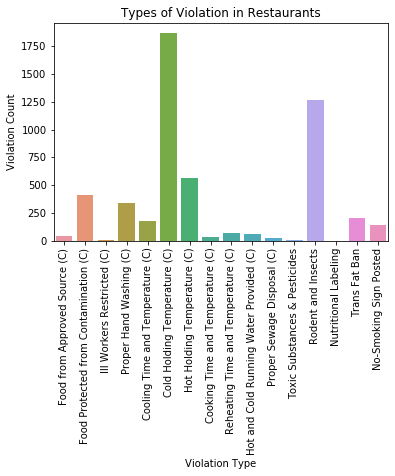

```python
sns.barplot(x=df_violation['Violation Type'], y=df_violation.Count);
plt.ylabel('Violation Count')
plt.title('Types of Violation in Restaurants')
plt.xticks(rotation='vertical');
```

## Step 3.2 - Created a line graph that shows the percent of restaurant inspections that have at least one violation by month and year. Are inspections getting harder or easier over time? Is there a particular month where more restaurants pass?

```python
df2.head()
```

|  | Establishment ID | Name | Address 1 | Address 2 | City | Zip | Inspection Date | Inspection Year | Inspection Month | Inspection Year and Month | ... | Inspection Type | Owner | Category | Type | Latitude | Longitude | Location | Dummy_Restaurant | Number of Out of Compliances | Dummy_Inspection |
| --- | --- | --- | --- | --- | --- | --- | --- | --- | --- | --- | --- | --- | --- | --- | --- | --- | --- | --- | --- | --- | --- |
| 0 | 18628 | SUBWAY #22916 | 12193 DARNESTOWN RD. | NaN | GAITHERSBURG | 20878 | 2018-12-19 | 2018 | 12 | 2018-12 | ... | Monitoring | P. N. ENTERPRISES, LLC | Restaurant | Food | 39.1179 | -77.2524 | (39.1179, -77.2524) | 1 | 0 | 0 |
| 1 | 1059 | GIANT FOOD #0192 | 18250 FLOWER HILL WAY | NaN | GAITHERSBURG | 20879 | 2018-12-19 | 2018 | 12 | 2018-12 | ... | Comprehensive | GIANT OF MARYLAND, LLC | Market | Food | 39.1551 | -77.1659 | (39.1551, -77.1659) | 0 | 3 | 1 |
| 2 | 20933 | PIZZA BOLIS | 7831 EASTERN AVE. | NaN | SILVER SPRING | 20910 | 2018-12-19 | 2018 | 12 | 2018-12 | ... | Monitoring | K.M.MG INC | Restaurant | Food | 38.9853 | -77.0273 | (38.9853, -77.0273) | 1 | 0 | 0 |
| 3 | 22217 | GREENE TURTLE | 18101 TOWN CENTER DR | NaN | OLNEY | 20832 | 2017-12-13 | 2017 | 12 | 2017-12 | ... | Comprehensive | OLNEY GT, LLC. | Restaurant | Food | 39.1519 | -77.0619 | (39.1519, -77.0619) | 1 | 0 | 0 |
| 4 | 28408 | CRAVE | 7101 DEMOCRACY BLVD | SPACE #FC | BETHESDA | 20817 | 2018-12-13 | 2018 | 12 | 2018-12 | ... | Monitoring | CRAVE RESTAURANT BETHESDA LLC | Restaurant | Food | 39.0221 | -77.1471 | (39.0221, -77.1471) | 1 | 1 | 1 |

5 rows × 37 columns

```python
tabular=df2.groupby("Inspection Year and Month")['Dummy_Inspection'].mean()
tabular=tabular.to_frame()
tabular['Dummy_Inspection']=tabular['Dummy_Inspection']*100
tabular.head()
```

| Inspection Year and Month | Dummy_Inspection |
| --- | --- |
| 2017-09 | 48.085758 |
| 2017-10 | 42.512690 |
| 2017-11 | 40.172166 |
| 2017-12 | 40.098200 |
| 2018-01 | 38.671875 |

```python
#tabular['Inspection Year and Month']=tabular.index
#tabular.reset_index()
tabular.columns
```

```
Index(['Dummy_Inspection'], dtype='object')
```

```python
import plotly.express as px
```

[output not shown]

This could probably be because July-August is the peak season for travellers to come to the US, and in order to keep the restaurants in chec,k the inspections are strict and rigorous.

```python
dfx=df2[['Establishment ID',"Dummy_Inspection"]]
dfx.head(10)
```

|  | Establishment ID | Dummy_Inspection |
| --- | --- | --- |
| 0 | 18628 | 0 |
| 1 | 1059 | 1 |
| 2 | 20933 | 0 |
| 3 | 22217 | 0 |
| 4 | 28408 | 1 |
| 5 | 28011 | 1 |
| 6 | 27427 | 1 |
| 7 | 22419 | 1 |
| 8 | 21231 | 1 |
| 9 | 30673 | 0 |

```python
pd.set_option('mode.chained_assignment', None)
dfx['Index']=dfx.groupby('Establishment ID').cumcount()
dfx=dfx.pivot_table(values="Dummy_Inspection",index=['Establishment ID'],columns=["Index"],aggfunc='first')
```

```python
dfy=df2[(df2["Dummy_Restaurant"]==1)]
```

```python
dfy.head()
```

|  | Establishment ID | Name | Address 1 | Address 2 | City | Zip | Inspection Date | Inspection Year | Inspection Month | Inspection Year and Month | ... | Inspection Type | Owner | Category | Type | Latitude | Longitude | Location | Dummy_Restaurant | Number of Out of Compliances | Dummy_Inspection |
| --- | --- | --- | --- | --- | --- | --- | --- | --- | --- | --- | --- | --- | --- | --- | --- | --- | --- | --- | --- | --- | --- |
| 0 | 18628 | SUBWAY #22916 | 12193 DARNESTOWN RD. | NaN | GAITHERSBURG | 20878 | 2018-12-19 | 2018 | 12 | 2018-12 | ... | Monitoring | P. N. ENTERPRISES, LLC | Restaurant | Food | 39.1179 | -77.2524 | (39.1179, -77.2524) | 1 | 0 | 0 |
| 2 | 20933 | PIZZA BOLIS | 7831 EASTERN AVE. | NaN | SILVER SPRING | 20910 | 2018-12-19 | 2018 | 12 | 2018-12 | ... | Monitoring | K.M.MG INC | Restaurant | Food | 38.9853 | -77.0273 | (38.9853, -77.0273) | 1 | 0 | 0 |
| 3 | 22217 | GREENE TURTLE | 18101 TOWN CENTER DR | NaN | OLNEY | 20832 | 2017-12-13 | 2017 | 12 | 2017-12 | ... | Comprehensive | OLNEY GT, LLC. | Restaurant | Food | 39.1519 | -77.0619 | (39.1519, -77.0619) | 1 | 0 | 0 |
| 4 | 28408 | CRAVE | 7101 DEMOCRACY BLVD | SPACE #FC | BETHESDA | 20817 | 2018-12-13 | 2018 | 12 | 2018-12 | ... | Monitoring | CRAVE RESTAURANT BETHESDA LLC | Restaurant | Food | 39.0221 | -77.1471 | (39.0221, -77.1471) | 1 | 1 | 1 |
| 5 | 28011 | FIRST WATCH RESTAURANT #139 | 802 MUDDY BRANCH RD | NaN | GAITHERSBURG | 20878 | 2018-12-19 | 2018 | 12 | 2018-12 | ... | Monitoring | FIRST WATCH RESTAURANTS, INC | Restaurant | Food | 39.1137 | -77.2167 | (39.1137, -77.2167) | 1 | 1 | 1 |

5 rows × 37 columns

## Step 3.3 - Created a map that shows all of the restaurants. Colored the restaurants with at least one violation in red. Are there particular areas with more violations? Are there any trends?

```python
pd.set_option('mode.chained_assignment', None)
dfy['Number of Out of Compliances'] = dfy['Number of Out of Compliances'].astype(str)
dfy.dtypes
```

```
Establishment ID                                    int64
Name                                               object
Address 1                                          object
Address 2                                          object
City                                               object
Zip                                                 int64
Inspection Date                            datetime64[ns]
Inspection Year                                    object
Inspection Month                                   object
Inspection Year and Month                          object
Inspection Results                                 object
Food from Approved Source (C)                       int64
Food Protected from Contamination (C)               int64
Ill Workers Restricted (C)                          int64
Proper Hand Washing (C)                             int64
Cooling Time and Temperature (C)                    int64
Cold Holding Temperature (C)                        int64
Hot Holding Temperature (C)                         int64
Cooking Time and Temperature (C)                    int64
Reheating Time and Temperature (C)                  int64
Hot and Cold Running Water Provided (C)             int64
Proper Sewage Disposal (C)                          int64
Toxic Substances & Pesticides                       int64
Rodent and Insects                                  int64
Nutritional Labeling                               object
Trans Fat Ban                                       int64
No-Smoking Sign Posted                              int64
Inspection Type                                    object
Owner                                              object
Category                                           object
Type                                               object
Latitude                                          float64
Longitude                                         float64
Location                                           object
Dummy_Restaurant                                    int64
Number of Out of Compliances                       object
Dummy_Inspection                                    int64
dtype: object
```

```python
import plotly.graph_objects as go
```

```python
mapbox_access_token = 'pk.eyJ1IjoicGFydGhzYXJhaXlhIiwiYSI6ImNrMm80aWRqbzB6bGwzam50dHNoZTlkODMifQ.RF6vejyXpk8AgLLGG4qlqA'
```

```python
inspect_map_data = go.Scattermapbox(
        lon = dfy['Longitude'],
        lat = dfy['Latitude'],
        text = dfy['Name'] + '<br>'+dfy['Number of Out of Compliances']+'<br>'+dfy['Location'],
        hoverinfo='text',
        mode = 'markers',
        marker_color =dfy['Dummy_Inspection'],
        marker =dict(
          #color='red' ,
          color = dfy['Dummy_Inspection'],
          colorscale=[[0, 'grey'], [1, 'red']],
            opacity=0.5,

            size=7



)
)

inspect_map_layout = go.Layout(
        title = 'Restaurants with at least 1 inspection(in red),Restaurants with no inspection(in grey)',
        mapbox=go.layout.Mapbox(
            accesstoken=mapbox_access_token,
            zoom=1
        )
    )

class_map = go.Figure(data=inspect_map_data, layout=inspect_map_layout)
class_map.show()
```

[interactive chart not shown]

```python
df2.iloc[1:10,8:28]
```

|  | Inspection Month | Inspection Year and Month | Inspection Results | Food from Approved Source (C) | Food Protected from Contamination (C) | Ill Workers Restricted (C) | Proper Hand Washing (C) | Cooling Time and Temperature (C) | Cold Holding Temperature (C) | Hot Holding Temperature (C) | Cooking Time and Temperature (C) | Reheating Time and Temperature (C) | Hot and Cold Running Water Provided (C) | Proper Sewage Disposal (C) | Toxic Substances & Pesticides | Rodent and Insects | Nutritional Labeling | Trans Fat Ban | No-Smoking Sign Posted | Inspection Type |
| --- | --- | --- | --- | --- | --- | --- | --- | --- | --- | --- | --- | --- | --- | --- | --- | --- | --- | --- | --- | --- |
| 1 | 12 | 2018-12 | Critical Violations Corrected | 0 | 0 | 0 | 1 | 1 | 1 | 0 | 0 | 0 | 0 | 0 | 0 | 0 | NaN | 0 | 0 | Comprehensive |
| 2 | 12 | 2018-12 | No Critical Violations Noted | 0 | 0 | 0 | 0 | 0 | 0 | 0 | 0 | 0 | 0 | 0 | 0 | 0 | NaN | 0 | 0 | Monitoring |
| 3 | 12 | 2017-12 | No Critical Violations Noted | 0 | 0 | 0 | 0 | 0 | 0 | 0 | 0 | 0 | 0 | 0 | 0 | 0 | NaN | 0 | 0 | Comprehensive |
| 4 | 12 | 2018-12 | No Critical Violations Noted | 0 | 0 | 0 | 0 | 0 | 0 | 0 | 0 | 0 | 0 | 0 | 0 | 1 | NaN | 0 | 0 | Monitoring |
| 5 | 12 | 2018-12 | Critical Violations Corrected | 0 | 0 | 0 | 0 | 0 | 0 | 1 | 0 | 0 | 0 | 0 | 0 | 0 | NaN | 0 | 0 | Monitoring |
| 6 | 12 | 2018-12 | Critical Violations Corrected | 0 | 0 | 0 | 0 | 0 | 0 | 1 | 0 | 0 | 0 | 0 | 0 | 0 | NaN | 0 | 0 | Monitoring |
| 7 | 12 | 2017-12 | No Critical Violations Noted | 0 | 0 | 0 | 0 | 0 | 0 | 0 | 0 | 0 | 0 | 0 | 0 | 1 | NaN | 0 | 0 | Food Complaint |
| 8 | 12 | 2017-12 | Critical Violations Corrected | 0 | 0 | 0 | 0 | 0 | 1 | 0 | 0 | 0 | 0 | 0 | 0 | 1 | NaN | 0 | 0 | Comprehensive |
| 9 | 12 | 2018-12 | No Critical Violations Noted | 0 | 0 | 0 | 0 | 0 | 0 | 0 | 0 | 0 | 0 | 0 | 0 | 0 | NaN | 0 | 0 | Monitoring |

```python
dfcity=df2[df2["Proper Hand Washing (C)"]==1]
dfcity['Number of Out of Compliances'] = dfcity['Number of Out of Compliances'].astype(str)
```

```python
inspect_map_data = go.Scattermapbox(
        lon = dfcity['Longitude'],
        lat = dfcity['Latitude'],
        text = dfcity['Name'] + '<br>'+dfcity['Number of Out of Compliances']+'<br>'+dfcity['Location'],
        hoverinfo='text',
        mode = 'markers',
        #marker_color =dfy['Dummy_Inspection']
        marker =dict(
          color='red' ,
          #color = dfy['Dummy_Inspection'],
          #colorscale=[[0, 'grey'], [1, 'red']],
            opacity=0.5,

            size=7



)
)

inspect_map_layout = go.Layout(
        title = 'Proper Hand Washing Violation',
        mapbox=go.layout.Mapbox(
            accesstoken=mapbox_access_token,
            zoom=1
        )
    )

class_map = go.Figure(data=inspect_map_data, layout=inspect_map_layout)
class_map.show()
```

[interactive chart not shown]

To display the trends I filtered the data according to what violation had a dummy as 1 and mapped it using plotly

After rigorous analysis I found a cluster of restaurants that did not comply for Proper hands washing near Shady Grove Rd and Frederick Rd

These factors can be due to lack of :-

1)Hand hygiene training.

2)Manager certification.

3)Hand washing supplies located at the hand sinks.

4)Management encouragement of hand washing.